# Lab07

Matthew

In this class we will explore clustering and dimensionality reduction methods.

## K-means

Make up some input data where we know what the answer should be. rnorm gives random data

```r
tmp <- c(rnorm(30,-3),rnorm(30,3))
x <- cbind(x=tmp,y=rev(tmp))
head(x)
```

```
##               x        y
## [1,] -3.4792045 3.181238
## [2,] -0.7354102 2.348087
## [3,] -2.1889697 3.831825
## [4,] -1.8104775 4.147837
## [5,] -3.5550146 2.138966
## [6,] -3.2808189 1.537746
```

Quick plot of x to see the two groups at (-3,3) and (3,-3)

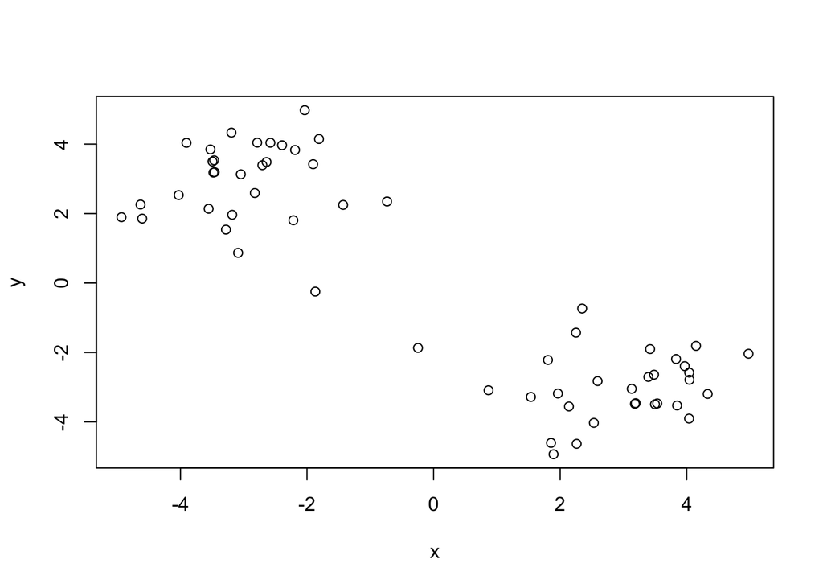

```r
plot(x)
```

Use the ‘kmeans()’ function setting k to 2 and nstart=20

```r
km <- kmeans(x,centers=2,nstart=20)
km
```

```
## K-means clustering with 2 clusters of sizes 30, 30
##
## Cluster means:
##           x         y
## 1  2.929038 -2.966525
## 2 -2.966525  2.929038
##
## Clustering vector:
##  [1] 2 2 2 2 2 2 2 2 2 2 2 2 2 2 2 2 2 2 2 2 2 2 2 2 2 2 2 2 2 2 1 1 1 1 1 1 1 1
## [39] 1 1 1 1 1 1 1 1 1 1 1 1 1 1 1 1 1 1 1 1 1 1
##
## Within cluster sum of squares by cluster:
## [1] 65.53124 65.53124
##  (between_SS / total_SS =  88.8 %)
##
## Available components:
##
## [1] "cluster"      "centers"      "totss"        "withinss"     "tot.withinss"
## [6] "betweenss"    "size"         "iter"         "ifault"
```

Q How many points are in each cluster?

```r
km$size
```

```
## [1] 30 30
```

Q. What ‘component’ of your result object details - cluster assignment/membership - cluster center?

```r
km$cluster
```

```
##  [1] 2 2 2 2 2 2 2 2 2 2 2 2 2 2 2 2 2 2 2 2 2 2 2 2 2 2 2 2 2 2 1 1 1 1 1 1 1 1
## [39] 1 1 1 1 1 1 1 1 1 1 1 1 1 1 1 1 1 1 1 1 1 1
```

```r
km$centers
```

```
##           x         y
## 1  2.929038 -2.966525
## 2 -2.966525  2.929038
```

Q. Plot x colored by the kmean cluster assignment and add cluster as blue points

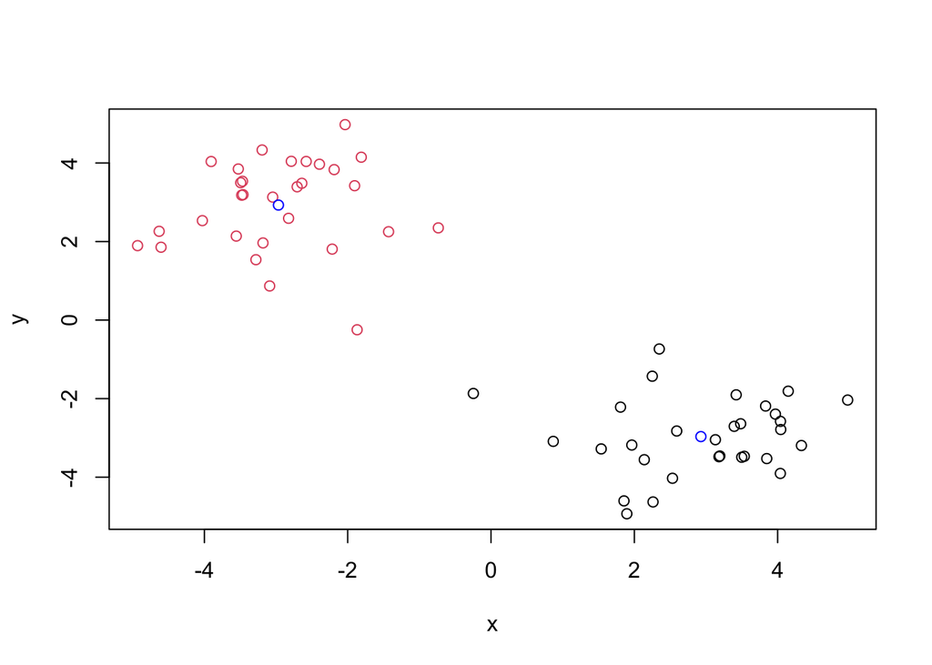

```r
plot(x,col=km$cluster)
points(km$centers,col="blue")
```

Play with kmeans and ask for different numbe of clusters

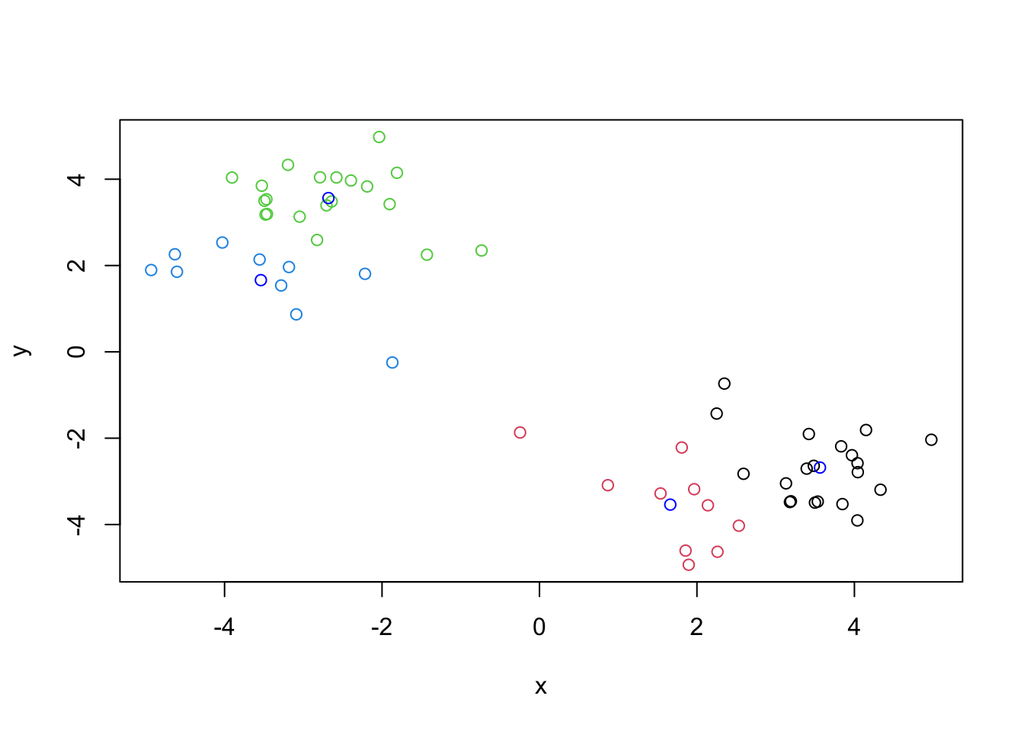

```r
km <- kmeans(x,centers=4,nstart=20)
plot(x,col=km$cluster)
points(km$centers,col="blue")
```

# Hierarchial Clustering

This is another very usefyl and widely employed clustering method which as the advantage over kmeans in that it can help reveal the something of the true grouping in your data

The ‘hclust()’ function wants a distance matrix as input. We can get this from the ‘dist()’ function

```r
d <- dist(x)
hc <- hclust(d)
hc
```

```
##
## Call:
## hclust(d = d)
##
## Cluster method   : complete
## Distance         : euclidean
## Number of objects: 60
```

There is a plot method for hclust results:

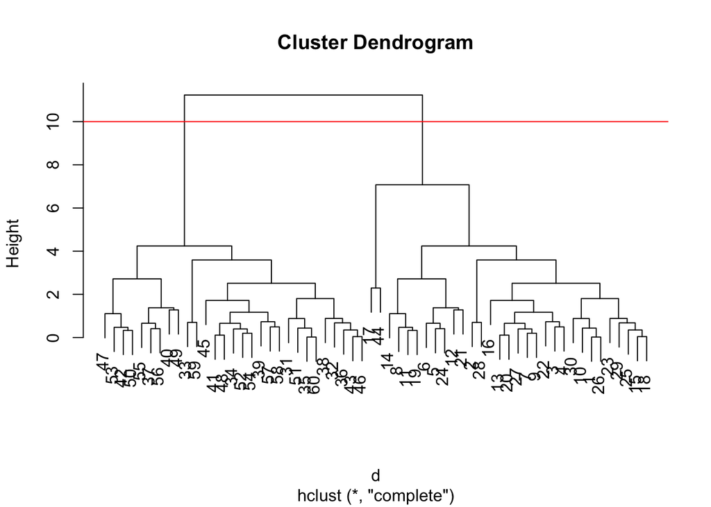

```r
plot(hc)
abline(h=10,col="red")
```

To get my cluster membership vector, I need to “cut” my tree to yield sub-trees or branches with all the members of a given cluster residing on the same cut branch. The function to do this is called ‘cutree()’

```r
grps <- cutree(hc,h=10)
grps
```

```
##  [1] 1 1 1 1 1 1 1 1 1 1 1 1 1 1 1 1 1 1 1 1 1 1 1 1 1 1 1 1 1 1 2 2 2 2 2 2 2 2
## [39] 2 2 2 2 2 1 2 2 2 2 2 2 2 2 2 2 2 2 2 2 2 2
```

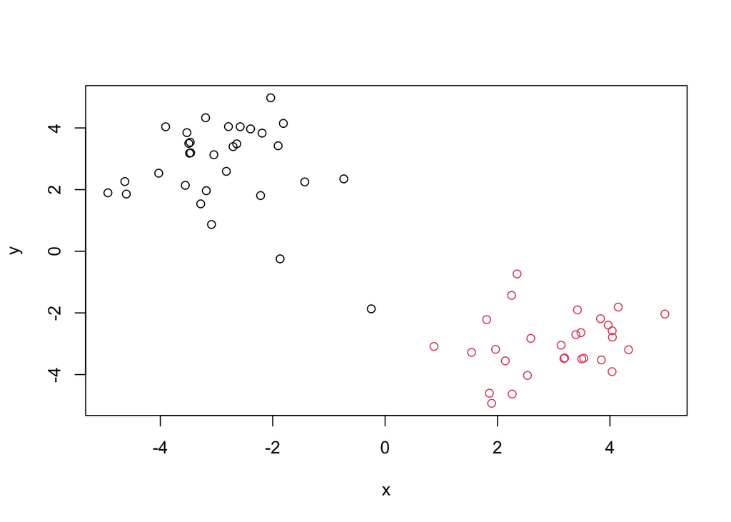

```r
plot(x,col=grps)
```

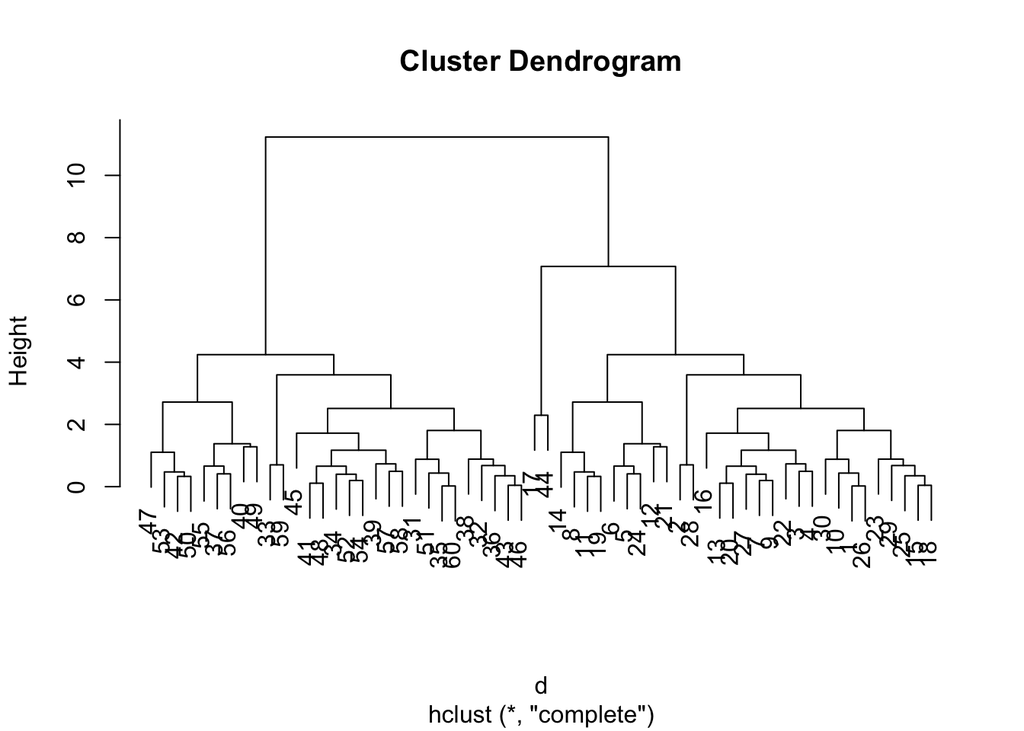

```r
plot(hc)
```

It is often helpful to use the ‘k=’ argument to cutree rather than the ‘h=’ height of cutting with ‘cutree()’. This will cut the tree to yield the number of clusters you want

```r
cutree(hc,k=4)
```

```
##  [1] 1 1 1 1 1 1 1 1 1 1 1 1 1 1 1 1 2 1 1 1 1 1 1 1 1 1 1 1 1 1 3 3 3 3 3 3 4 3
## [39] 3 4 3 4 3 2 3 3 4 3 4 4 3 3 4 3 4 4 3 3 3 3
```